# LBB1 - P4DS

Lam Yi Rong Yvonne

8/29/2019

# 1 Overview

This document is meant to show the step-by-step transformation code of the ‘retail.csv’ dataset that is provided in the first week of the P4DS module.

# 2 Reading Data

Dataset to be read into R.

```r
retail <- read.csv("retail.csv")
```

# 3 Clean up Data

Take a peek into the raw data to get a sense of how to clean it up.

```r
str(retail)
head(retail)

#Row.ID and Order.ID are unnecessary data (columns 1 & 2), hence it will be removed.
retail <- retail[,-c(1:2)]
retail

#Turn Order.Date and Ship.Date from factors to dates using explicit coercion, as they are not categorical factors.
retail$Ship.Date <- as.Date(retail$Ship.Date, "%m/%d/%y")
retail$Order.Date <- as.Date(retail$Order.Date, "%m/%d/%y")
head(retail)

#Turn Customer.ID, Product.ID and Product.Name from factors to characters using explicit coercion as well.
retail$Customer.ID <- as.character(retail$Customer.ID)
retail$Product.ID <- as.character(retail$Product.ID)
retail$Product.Name <- as.character(retail$Product.Name)
head(retail)
```

# 4 Feature Engineering

New columns are created to turn the 2 date columns into columns which are worthwhile analysing.

```r
#Create new columns to categorise dates into weekdays and weekends.
#First, classify the dates into days of the week
retail$Ship.Days <- weekdays(retail$Ship.Date)
retail$Order.Days <- weekdays(retail$Order.Date)

#Second, further classify the days of the week into weekdays and weekends
retail$Ship.Wkends <- ifelse(retail$Ship.Days == "Saturday"|retail$Ship.Days == "Sunday","Weekend","Weekday")
retail$Order.Wkends <- ifelse(retail$Order.Days == "Saturday"|retail$Order.Days == "Sunday", "Weekend","Weekday")
head(retail)
```

```
##   Order.Date  Ship.Date      Ship.Mode Customer.ID   Segment
## 1 2016-11-08 2016-11-11   Second Class    CG-12520  Consumer
## 2 2016-11-08 2016-11-11   Second Class    CG-12520  Consumer
## 3 2016-06-12 2016-06-16   Second Class    DV-13045 Corporate
## 4 2015-10-11 2015-10-18 Standard Class    SO-20335  Consumer
## 5 2015-10-11 2015-10-18 Standard Class    SO-20335  Consumer
## 6 2014-06-09 2014-06-14 Standard Class    BH-11710  Consumer
##        Product.ID        Category Sub.Category
## 1 FUR-BO-10001798       Furniture    Bookcases
## 2 FUR-CH-10000454       Furniture       Chairs
## 3 OFF-LA-10000240 Office Supplies       Labels
## 4 FUR-TA-10000577       Furniture       Tables
## 5 OFF-ST-10000760 Office Supplies      Storage
## 6 FUR-FU-10001487       Furniture  Furnishings
##                                                       Product.Name
```

[output cut: 20 more lines]

# 5 Exploratory Data Analysis

Once the data becomes more manageable, some analysis can be performed.

Which Categories and Segments make up the bulk of the purchases?

```r
prop.table(table(retail$Category,retail$Segment))*100
```

```
##
##                    Consumer Corporate Home Office
##   Furniture       11.136682  6.463878    3.622173
##   Office Supplies 31.288773 18.210927   10.796478
##   Technology       9.515709  5.543326    3.422053
```

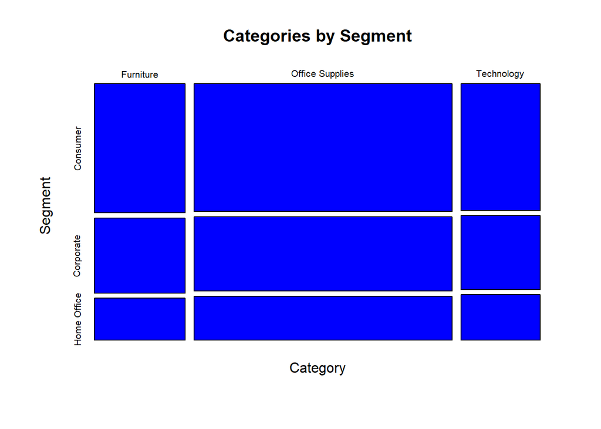

```r
plot(table(retail$Category,retail$Segment), xlab = "Category", ylab = "Segment", main = "Categories by Segment", col = "blue")
```

From the plot, we can see that the Office Supplies category makes the bulk of sales quantity and the Consumer segment contributes to the bulk of the purchases.

Which is the most profitable category?

```r
mean_profit <- aggregate(Profit ~ Sub.Category + Category, retail, mean)
mean_profit[order(-mean_profit$Profit),]
```

```
##    Sub.Category        Category     Profit
## 15      Copiers      Technology 817.909190
## 14  Accessories      Technology  54.111788
## 17       Phones      Technology  50.073938
## 2        Chairs       Furniture  43.095894
## 5    Appliances Office Supplies  38.922758
## 16     Machines      Technology  29.432669
## 8     Envelopes Office Supplies  27.418019
## 12      Storage Office Supplies  25.152277
## 11        Paper Office Supplies  24.856620
## 7       Binders Office Supplies  19.843574
## 10       Labels Office Supplies  15.236962
## 3   Furnishings       Furniture  13.645918
## 6           Art Office Supplies   8.200737
## 9     Fasteners Office Supplies   4.375660
## 13     Supplies Office Supplies  -6.258418
## 1     Bookcases       Furniture -15.230509
## 4        Tables       Furniture -55.565771
```

The most profitable category is Technology, with Copiers Accessories and Phones recording the three highest mean Profit respectively.

```r
mean_profit2 <- aggregate(Profit ~ Sub.Category + Category, retail, sum)
mean_profit2[order(-mean_profit2$Profit),]
```

```
##    Sub.Category        Category      Profit
## 15      Copiers      Technology  55617.8249
## 17       Phones      Technology  44515.7306
## 14  Accessories      Technology  41936.6357
## 11        Paper Office Supplies  34053.5693
## 7       Binders Office Supplies  30221.7633
## 2        Chairs       Furniture  26590.1663
## 12      Storage Office Supplies  21278.8264
## 5    Appliances Office Supplies  18138.0054
## 3   Furnishings       Furniture  13059.1436
## 8     Envelopes Office Supplies   6964.1767
## 6           Art Office Supplies   6527.7870
## 10       Labels Office Supplies   5546.2540
## 16     Machines      Technology   3384.7569
## 9     Fasteners Office Supplies    949.5182
## 13     Supplies Office Supplies  -1189.0995
## 1     Bookcases       Furniture  -3472.5560
## 4        Tables       Furniture -17725.4811
```

However, if we take a look at the sum of profits, Paper and Binders in the Sub.Category has taken over the 4th and 5th highest Profit ranks (previously held by Chairs and Appliances respectively). Even though the mean profit margin of Papers and Binders are relatively low, there is high demand for such products, hence the overall profit sum of these categories are high as well.

On the other hand, sub categories such as Tables and Bookcases are recording losses. In order to cut losses for these sub categories, the company could reduce the focus on these sub categories by reducing the number of products they carry in these sub categories. Another way could be to explore ways to reduce the cost of these products to the company whilst maintaining a good profit margin. There could be many factors which resulted in the high cost incurred to the company such as high shipping costs and storage costs (information which is not available in this data).

Are more products shipped during the weekdays or the weekends?

```r
table(retail$Category,retail$Ship.Wkends)
```

```
##
##                   Weekday Weekend
##   Furniture          1589     532
##   Office Supplies    4440    1586
##   Technology         1348     499
```

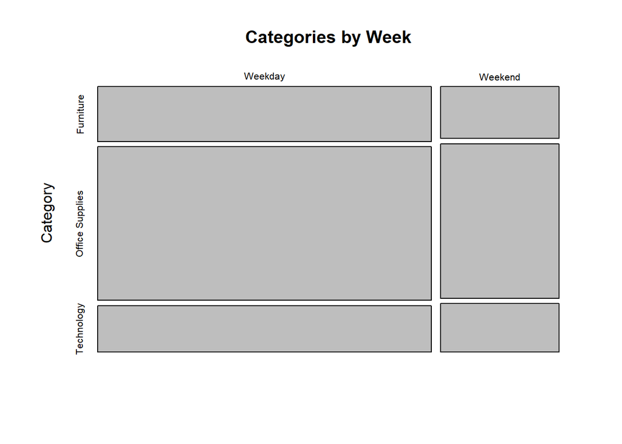

```r
plot(table(retail$Ship.Wkends, retail$Category), ylab = "Category", main = "Categories by Week" )
```

It is be observed that majority of the purchases are shipped during the weekdays.

# 6 Findings

The company should focus on marketing and selling their products in the Technology and Office Supplies category. In addition, the company should consider employing more staff or allocate more human resources to handle the high delivery amount of their products during the weekdays so as to deliver and maintain a fast and smooth purchasing experience for their customers.